# Peer Assessment 1

Peer Assesment exercise for coursera MOOC “Reproducible Research” in the specialization “Data Science”

### Loading and preprocessing the data

First, being the working directory set where the [repo’s files are](https://github.com/rdpeng/RepData_PeerAssessment1), we unzip, read the data and load the necessary packages.

```r
unzip("activity.zip")
data <- read.csv("activity.csv")
library(lattice)
library(plyr)
library(dplyr)
```

### What is mean total number of steps taken per day?

1. Make a histogram of the total number of steps taken each day
2. Calculate and report the mean and median total number of steps taken per day

Now, we plot the total number of steps per day and get the mean and median from this total.

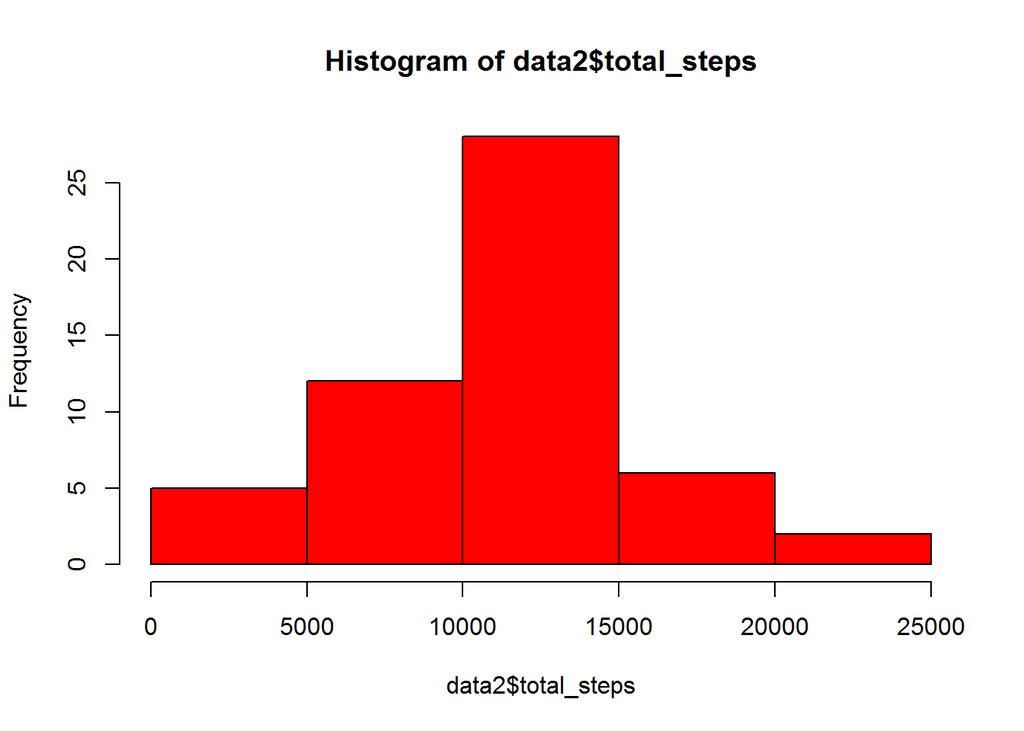

```r
data2 <- group_by(data, date) %>%
        filter(!is.na(steps)) %>%
        summarise(total_steps = sum(steps))
hist(data2$total_steps, col="red")
```

```r
mean(data2$total_steps, na.rm=TRUE)
```

```
## [1] 10766.19
```

```r
median(data2$total_steps, na.rm=TRUE)
```

```
## [1] 10765
```

### What is the average daily activity pattern?

1. Make a time series plot (i.e. type = “l”) of the 5-minute interval (x-axis) and the average number of steps taken, averaged across all days (y-axis)
2. Which 5-minute interval, on average across all the days in the dataset, contains the maximum number of steps?

For this part, we first make a data frame with the average steps per day 5-minute interval and then plot the averages by their intervals:

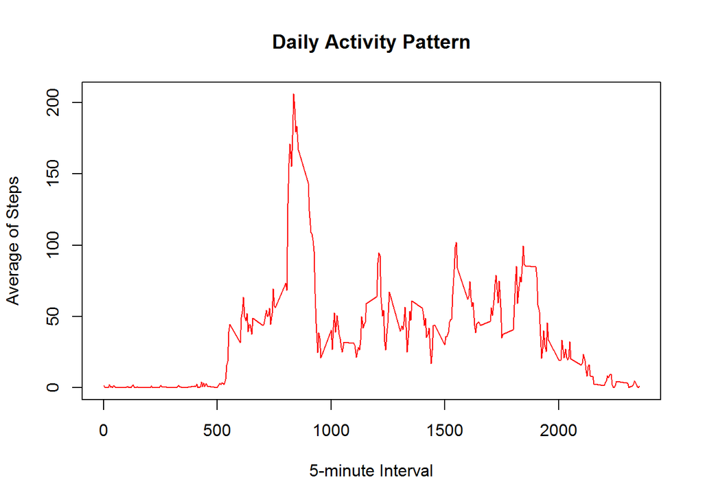

```r
data3 <- group_by(data, interval) %>%
        filter(!is.na(steps)) %>%
        summarise(avg_steps = mean(steps))
plot(data3$interval, data3$avg_steps
     , type="l", col="red"
     , main="Daily Activity Pattern"
     , xlab="5-minute Interval", ylab="Average of Steps")
```

And now we see which interval has the maximun number of steps on average across all days:

```r
data3[which.max(data3$avg_steps), 1]
```

```
## Source: local data frame [1 x 1]
##
##   interval
## 1      835
```

### Imputing missing values

Note that there are a number of days/intervals where there are missing values (coded as NA). The presence of missing days may introduce bias into some calculations or summaries of the data.

1. Calculate and report the total number of missing values in the dataset (i.e. the total number of rows with NAs)

```r
sum(is.na(data$steps))
```

```
## [1] 2304
```

2. Devise a strategy for filling in all of the missing values in the dataset. The strategy does not need to be sophisticated. For example, you could use the mean/median for that day, or the mean for that 5-minute interval, etc.
3. Create a new dataset that is equal to the original dataset but with the missing data filled in.

```r
impute.mean <- function(x) replace(x, is.na(x), mean(x, na.rm = TRUE))
dataNA <- ddply(data, ~ interval, transform, steps = impute.mean(steps))
dataNA <- dataNA[order(dataNA$date), ]
```

4. Make a histogram of the total number of steps taken each day and Calculate and report the mean and median total number of steps taken per day. Do these values differ from the estimates from the first part of the assignment? What is the impact of imputing missing data on the estimates of the total daily number of steps?

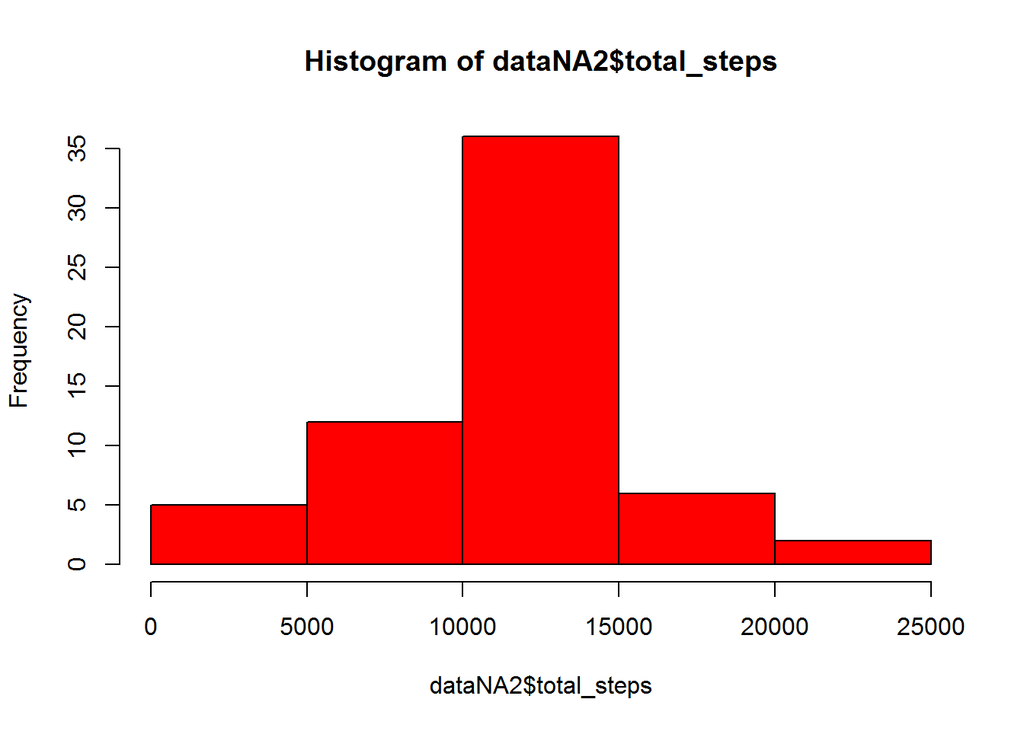

```r
dataNA2 <- group_by(dataNA, date) %>%
        summarise(total_steps = sum(steps))
hist(dataNA2$total_steps, col="red")
```

```r
mean(dataNA2$total_steps)
```

```
## [1] 10766.19
```

```r
median(dataNA2$total_steps)
```

```
## [1] 10766.19
```

## Are there differences in activity patterns between weekdays and weekends?

Now we plot the daily activity patterns with the imputed NAs for weekdays and weekend days.

```r
Sys.setlocale("LC_TIME", "English")
```

```
## [1] "English_United States.1252"
```

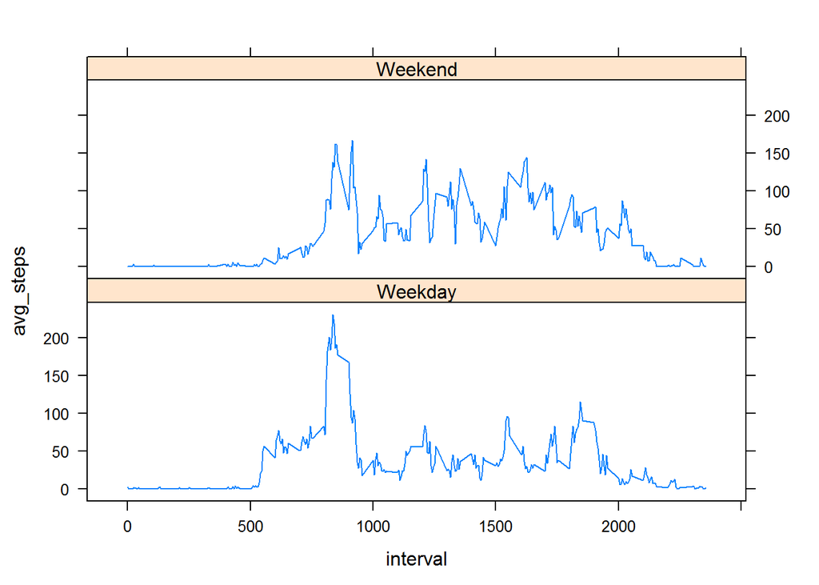

```r
dataNA$date <- as.character(dataNA$date)
dataNA$date <- as.Date(dataNA$date)

datadays <- mutate(dataNA, weekdays = weekdays(dataNA$date))
datadays$weekdays2[datadays$weekdays=="Monday"] <- "Weekday"
datadays$weekdays2[datadays$weekdays=="Tuesday"] <- "Weekday"
datadays$weekdays2[datadays$weekdays=="Wednesday"] <- "Weekday"
datadays$weekdays2[datadays$weekdays=="Thursday"] <- "Weekday"
datadays$weekdays2[datadays$weekdays=="Friday"] <- "Weekday"

datadays$weekdays2[datadays$weekdays=="Saturday"] <- "Weekend"
datadays$weekdays2[datadays$weekdays=="Sunday"] <- "Weekend"

datadays$weekdays2 <- as.factor(datadays$weekdays2)

datadays2 <- group_by(datadays, interval, weekdays2) %>%
        summarise(avg_steps = mean(steps))
xyplot(avg_steps ~ interval | weekdays2, data = datadays2, layout = c(1,2), type="l")
```